# Practical 2

## Question 1:

aesthetics: hits mapped to x (horizontal coordinate), home runs mapped to y (vertical coordinate)

geoms: geom_point (scatter plot), geom_dens_2d (contour plot)

scales: continuous horizontal and vertical axes

facets: no facets

coords&transformations: plain Cartesian grid

## Question 2:

2. **Run the code below to generate data. There will be three vectors in your environment. Put them in a data frame for entering it in a `ggplot()` call using either the `data.frame()` or the `tibble()` function. Give informative names and make sure the types are correct (use the `as.<type>()` functions). Name the result `gg_students`**

```r
set.seed(1234)
student_grade  <- rnorm(32, 7)
student_number <- round(runif(32) * 2e6 + 5e6)
programme      <- sample(c("Science", "Social Science"), 32, replace = TRUE)
```

```r
gg_students <- data.frame(
  id = as.character(student_number),
  grade = as.numeric(student_grade),
  programme = as.factor(programme)
  )
gg_students
```

```
##         id    grade      programme
## 1  5478051 5.792934 Social Science
## 2  6412989 7.277429        Science
## 3  5616190 8.084441 Social Science
## 4  6017095 4.654302 Social Science
## 5  5103293 7.429125 Social Science
## 6  6129140 7.506056        Science
## 7  5242960 6.425260        Science
## 8  6785673 6.453368        Science
## 9  5029255 6.435548        Science
## 10 6566242 6.109962 Social Science
## 11 5179923 6.522807        Science
## 12 6038380 6.001614 Social Science
## 13 5768533 6.223746        Science
## 14 5140105 7.064459        Science
```

[output cut: 18 more lines]

## Question 3:

**Plot the first homeruns_plot again, but map the Hits to the y-axis and the HmRun to the x-axis instead.**

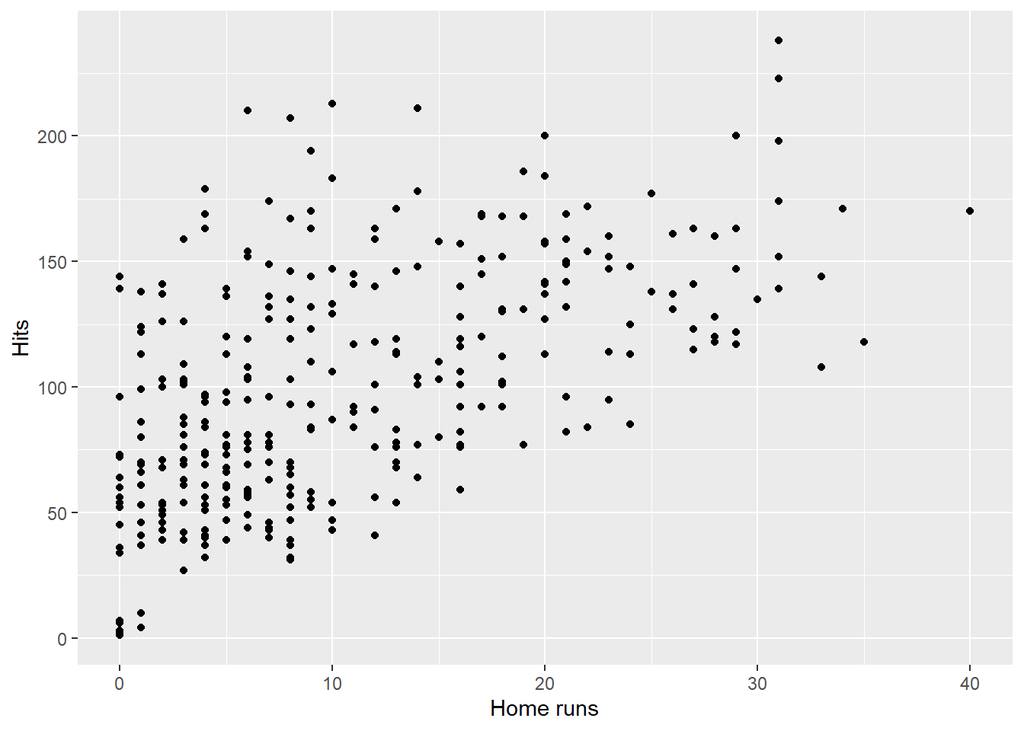

```r
ggplot(Hitters, aes(x = HmRun, y = Hits)) +
  geom_point() +
  labs(y = "Hits", x = "Home runs")
```

## Question 4:

**Recreate the same plot once more, but now also map the variable League to the colour aesthetic and the variable Salary to the size aesthetic.**

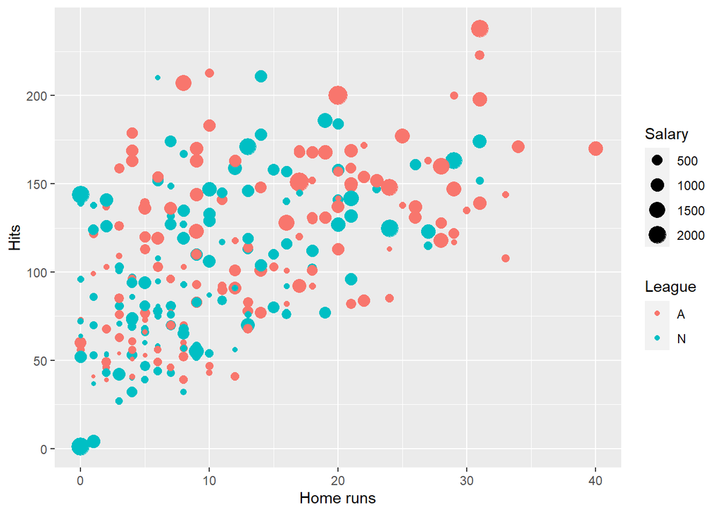

```r
ggplot(Hitters, aes(x = HmRun, y = Hits, colour = League, size = Salary)) +
  geom_point() +
  labs(y = "Hits", x = "Home runs")
```